# Lab 2

Emil Luusua

25 September 2019

## Question 1

We create a Hidden Markov Model (HMM) with a hidden state Z_t that takes values z0-z9 which represent the sector where the robot is at time step t, and an observed random variable X_t that takes values x0-x9 which represent the reading of the tracking device at time step t. The transition probabilities are 0.5 to stay in the current state, and 0.5 to move to the next one. The emission probabilities are 0.2 to observe any of the states within 2 steps of the actual one.

```r
states <- c('z0', 'z1', 'z2', 'z3', 'z4', 'z5', 'z6', 'z7', 'z8', 'z9')
symbols <- c('x0', 'x1', 'x2', 'x3', 'x4', 'x5', 'x6', 'x7', 'x8', 'x9')
transProbs <- matrix(c(
  c(0.5, 0, 0, 0, 0, 0, 0, 0, 0, 0.5),
  c(0.5, 0.5, 0, 0, 0, 0, 0, 0, 0, 0),
  c(0, 0.5, 0.5, 0, 0, 0, 0, 0, 0, 0),
  c(0, 0, 0.5, 0.5, 0, 0, 0, 0, 0, 0),
  c(0, 0, 0, 0.5, 0.5, 0, 0, 0, 0, 0),
  c(0, 0, 0, 0, 0.5, 0.5, 0, 0, 0, 0),
  c(0, 0, 0, 0, 0, 0.5, 0.5, 0, 0, 0),
  c(0, 0, 0, 0, 0, 0, 0.5, 0.5, 0, 0),
  c(0, 0, 0, 0, 0, 0, 0, 0.5, 0.5, 0),
  c(0, 0, 0, 0, 0, 0, 0, 0, 0.5, 0.5)), 10)
emissionProbs <- matrix(c(
  c(0.2, 0.2, 0.2, 0, 0, 0, 0, 0, 0.2, 0.2),
  c(0.2, 0.2, 0.2, 0.2, 0, 0, 0, 0, 0, 0.2),
  c(0.2, 0.2, 0.2, 0.2, 0.2, 0, 0, 0, 0, 0),
  c(0, 0.2, 0.2, 0.2, 0.2, 0.2, 0, 0, 0, 0),
  c(0, 0, 0.2, 0.2, 0.2, 0.2, 0.2, 0, 0, 0),
  c(0, 0, 0, 0.2, 0.2, 0.2, 0.2, 0.2, 0, 0),
  c(0, 0, 0, 0, 0.2, 0.2, 0.2, 0.2, 0.2, 0),
  c(0, 0, 0, 0, 0, 0.2, 0.2, 0.2, 0.2, 0.2),
  c(0.2, 0, 0, 0, 0, 0, 0.2, 0.2, 0.2, 0.2),
  c(0.2, 0.2, 0, 0, 0, 0, 0, 0.2, 0.2, 0.2)), 10)

hmm <- initHMM(states, symbols, transProbs = transProbs, emissionProbs = emissionProbs)
```

## Question 2

```r
simulation <- simHMM(hmm, 100)
print(simulation)
```

```
## $states
##   [1] "z1" "z1" "z1" "z2" "z2" "z2" "z2" "z3" "z3" "z3" "z3" "z4" "z5" "z5"
##  [15] "z5" "z5" "z5" "z6" "z7" "z7" "z7" "z8" "z9" "z9" "z0" "z1" "z1" "z2"
##  [29] "z2" "z3" "z3" "z4" "z4" "z4" "z4" "z4" "z4" "z4" "z5" "z5" "z6" "z7"
##  [43] "z8" "z9" "z9" "z0" "z1" "z2" "z2" "z3" "z3" "z3" "z3" "z3" "z4" "z4"
##  [57] "z4" "z4" "z4" "z4" "z4" "z5" "z6" "z7" "z7" "z7" "z7" "z8" "z9" "z9"
##  [71] "z0" "z0" "z0" "z1" "z2" "z3" "z4" "z4" "z5" "z6" "z7" "z8" "z9" "z0"
##  [85] "z0" "z1" "z2" "z3" "z3" "z3" "z4" "z5" "z5" "z5" "z6" "z6" "z7" "z7"
##  [99] "z7" "z7"
##
## $observation
##   [1] "x0" "x2" "x0" "x2" "x4" "x4" "x2" "x3" "x3" "x4" "x1" "x2" "x3" "x7"
##  [15] "x7" "x4" "x4" "x8" "x8" "x5" "x8" "x7" "x8" "x8" "x2" "x9" "x0" "x4"
##  [29] "x4" "x4" "x5" "x2" "x5" "x6" "x6" "x5" "x5" "x3" "x5" "x4" "x6" "x5"
##  [43] "x0" "x0" "x7" "x0" "x0" "x2" "x0" "x4" "x2" "x1" "x3" "x3" "x2" "x3"
##  [57] "x3" "x6" "x4" "x2" "x4" "x4" "x7" "x6" "x9" "x9" "x5" "x7" "x1" "x0"
##  [71] "x2" "x1" "x0" "x9" "x2" "x3" "x2" "x4" "x7" "x8" "x8" "x6" "x9" "x1"
##  [85] "x2" "x0" "x0" "x2" "x5" "x2" "x2" "x5" "x3" "x7" "x6" "x6" "x9" "x5"
##  [99] "x7" "x6"
```

## Question 3

```r
observations <- simulation$observation

alpha <- exp(forward(hmm, observations))
filtered <- prop.table(alpha, 2)
smoothed <- posterior(hmm, observations)
most_probable_path <- viterbi(hmm, observations)
```

## Question 4

```r
most_probable_state <- function(x) {
  idx <- which.max(x)
  return(states[idx])
}

filtered_predictions <- apply(filtered, 2, most_probable_state)
smoothed_predictions <- apply(smoothed, 2, most_probable_state)
```

Accuracy of Viterbi algorithm

```r
viterbi_results <- table(most_probable_path == simulation$states)
print(viterbi_results['TRUE'] / sum(viterbi_results))
```

```
## TRUE
## 0.53
```

Accuracy of filtered distribution

```r
filtered_results <- table(filtered_predictions == simulation$states)
print(filtered_results['TRUE'] / sum(filtered_results))
```

```
## TRUE
##  0.5
```

Accuracy of smoothed distribution

```r
smoothed_results <- table(smoothed_predictions == simulation$states)
print(smoothed_results['TRUE'] / sum(smoothed_results))
```

```
## TRUE
## 0.73
```

## Question 5

Repeat the exact same approach 10 times and print out the accuracies.

```r
viterbi_accuracies <- list()
filtered_accuracies <- list()
smoothed_accuracies <- list()

for(i in 1:10) {
  simulation <- simHMM(hmm, 100)
  observations <- simulation$observation

  alpha <- exp(forward(hmm, observations))
  filtered <- prop.table(alpha, 2)
  smoothed <- posterior(hmm, observations)
  most_probable_path <- viterbi(hmm, observations)

  filtered_predictions <- apply(filtered, 2, most_probable_state)
  smoothed_predictions <- apply(smoothed, 2, most_probable_state)

  viterbi_results <- table(most_probable_path == simulation$states)
  viterbi_accuracies <- append(viterbi_accuracies, viterbi_results['TRUE'] / sum(viterbi_results))

  filtered_results <- table(filtered_predictions == simulation$states)
  filtered_accuracies <- append(filtered_accuracies, filtered_results['TRUE'] / sum(filtered_results))

  smoothed_results <- table(smoothed_predictions == simulation$states)
  smoothed_accuracies <- append(smoothed_accuracies, smoothed_results['TRUE'] / sum(smoothed_results))
}

accuracies <- matrix(c(viterbi_accuracies, filtered_accuracies, smoothed_accuracies), 3, byrow=TRUE)
dimnames(accuracies) <- list(c('Viterbi', 'Filtered', 'Smoothed'))
print(accuracies)
```

```
##          [,1] [,2] [,3] [,4] [,5] [,6] [,7] [,8] [,9] [,10]
## Viterbi  0.5  0.51 0.46 0.52 0.43 0.47 0.56 0.56 0.45 0.64
## Filtered 0.5  0.43 0.61 0.5  0.55 0.49 0.52 0.53 0.57 0.44
## Smoothed 0.74 0.61 0.69 0.64 0.64 0.62 0.78 0.66 0.66 0.59
```

## Question 6

With exception for the global maximum at t=0, it seems like an increased number of observations does not increase confidence in where the robot is.

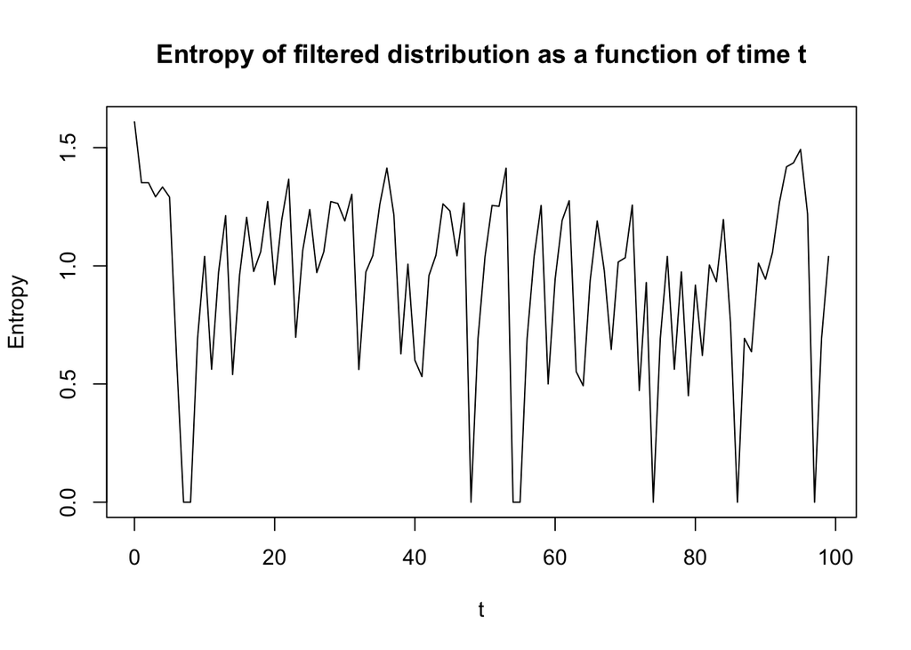

```r
plot(0:99, apply(filtered, 2, entropy.empirical), type = 'l', xlab = 't', ylab = 'Entropy',
     main = 'Entropy of filtered distribution as a function of time t')
```

## Question 7

We seek to compute
$$p(Z^{101}|x^{0:100}) = \sum_{z^t} p(Z^{101}|z^{100})p(z^{100}|x^{0:100})$$
where $p(Z^{101}|z^{100})$ is the transition probability and $p(z^{100}|x^{0:100})$ is the filtered probability distribution.

```r
probs <- list()

for (Z in states) {
  prob <- 0

  for (z in states) {
    prob <- prob + hmm$transProbs[z, Z] * filtered[z, 100]
  }

  probs <- append(probs, prob)
}
probs <- array(unlist(probs))
dimnames(probs) <- list(states)
print(probs)
```

```
##    z0    z1    z2    z3    z4    z5    z6    z7    z8    z9
## 0.000 0.000 0.125 0.375 0.375 0.125 0.000 0.000 0.000 0.000
```